# Project: Investigate a Gapminder dataset on per capita education expenditure by countries and its correlation to GDP per capita

```python
df_pr_ed_v2
```

| country | 1995 | 1996 | 1997 | 1998 | 1999 | 2000 | 2001 | 2002 | 2003 | 2004 | 2005 | 2006 | 2007 | 2008 | 2009 | 2010 | 2011 | 2012 | 2013 |
| --- | --- | --- | --- | --- | --- | --- | --- | --- | --- | --- | --- | --- | --- | --- | --- | --- | --- | --- | --- |
| Afghanistan | 9.065000 | 9.065000 | 9.065000 | 9.065000 | 9.065000 | 9.065000 | 9.065000 | 9.065000 | 9.065000 | 9.065000 | 9.065000 | 9.065000 | 9.065000 | 9.065000 | 9.065000 | 9.730000 | 10.100000 | 7.120000 | 9.310000 |
| Albania | NaN | NaN | NaN | NaN | NaN | NaN | NaN | NaN | NaN | NaN | NaN | NaN | NaN | NaN | NaN | NaN | NaN | NaN | NaN |
| Andorra | 12.115556 | 12.115556 | 12.115556 | 12.115556 | 12.115556 | 12.115556 | 12.115556 | 7.780000 | 12.115556 | 7.970000 | 7.440000 | 9.730000 | 9.920000 | 12.115556 | 15.700000 | 17.100000 | 17.800000 | 12.115556 | 15.600000 |
| Antigua and Barbuda | 8.690000 | 8.690000 | 8.690000 | 8.690000 | 8.690000 | 8.690000 | 8.690000 | 8.690000 | 8.690000 | 8.690000 | 8.690000 | 8.690000 | 8.690000 | 8.690000 | 8.690000 | 8.690000 | 8.690000 | 8.690000 | 8.690000 |
| Argentina | 12.561250 | 12.561250 | 12.561250 | 11.000000 | 12.500000 | 12.400000 | 13.800000 | 10.800000 | 10.500000 | 9.880000 | 10.400000 | 11.600000 | 12.700000 | 13.700000 | 14.800000 | 13.700000 | 14.200000 | 14.600000 | 14.400000 |
| Armenia | 10.900000 | 10.900000 | 10.900000 | 10.900000 | 10.900000 | 10.900000 | 10.900000 | 10.900000 | 10.900000 | 10.900000 | 10.900000 | 10.900000 | 10.900000 | 10.900000 | 10.900000 | 10.900000 | 10.900000 | 10.800000 | 11.000000 |
| Australia | 15.600000 | 18.381818 | 18.381818 | 18.381818 | 18.381818 | 16.700000 | 18.381818 | 18.381818 | 18.381818 | 18.381818 | 17.900000 | 17.700000 | 17.300000 | 17.600000 | 19.900000 | 22.400000 | 20.100000 | 18.200000 | 18.800000 |
| Austria | 23.237500 | 23.237500 | 23.237500 | 24.500000 | 24.400000 | 22.500000 | 22.400000 | 22.900000 | 22.600000 | 22.000000 | 22.600000 | 22.600000 | 22.200000 | 23.200000 | 25.100000 | 24.900000 | 24.600000 | 21.900000 | 23.400000 |
| Bahrain | 10.500000 | 10.500000 | 10.500000 | 10.500000 | 10.500000 | 10.500000 | 10.500000 | 10.500000 | 10.500000 | 10.500000 | 10.500000 | 10.500000 | 10.500000 | 10.500000 | 10.500000 | 10.500000 | 10.500000 | 10.500000 | 10.500000 |
| Bangladesh | 8.232000 | 8.232000 | 8.232000 | 8.232000 | 8.232000 | 8.232000 | 8.232000 | 8.232000 | 8.232000 | 8.232000 | 8.232000 | 7.820000 | 8.930000 | 8.420000 | 7.690000 | 8.232000 | 8.300000 | 8.232000 | 8.232000 |
| Barbados | 17.775000 | 17.775000 | 17.775000 | 17.775000 | 10.500000 | 14.000000 | 19.300000 | 17.700000 | 19.300000 | 19.700000 | 19.000000 | 17.775000 | 17.775000 | 22.700000 | 17.775000 | 17.775000 | 17.775000 | 17.775000 | 17.775000 |
| Belgium | 20.316667 | 20.316667 | 20.316667 | 20.316667 | 20.316667 | 20.316667 | 17.800000 | 17.900000 | 19.200000 | 19.200000 | 19.300000 | 19.800000 | 19.900000 | 21.800000 | 21.500000 | 22.400000 | 22.300000 | 20.316667 | 22.700000 |
| Belize | 15.340000 | 15.340000 | 15.340000 | 15.340000 | 16.900000 | 15.700000 | 15.340000 | 15.340000 | 15.340000 | 12.400000 | 13.700000 | 14.100000 | 15.340000 | 15.400000 | 16.100000 | 18.200000 | 15.340000 | 15.000000 | 15.900000 |
| Benin | 11.150000 | 11.150000 | 11.150000 | 11.150000 | 11.150000 | 10.900000 | 12.000000 | 10.100000 | 10.000000 | 10.500000 | 10.100000 | 11.300000 | 11.150000 | 11.500000 | 12.400000 | 13.700000 | 11.150000 | 10.800000 | 10.500000 |
| Bhutan | 8.715714 | 8.715714 | 8.715714 | 8.715714 | 8.715714 | 8.715714 | 8.715714 | 8.715714 | 8.715714 | 8.240000 | 10.400000 | 8.715714 | 8.715714 | 7.370000 | 9.110000 | 7.910000 | 9.670000 | 8.715714 | 8.310000 |
| Botswana | 13.966667 | 13.966667 | 13.966667 | 13.966667 | 13.966667 | 13.966667 | 13.966667 | 13.966667 | 13.966667 | 13.966667 | 17.800000 | 13.966667 | 13.900000 | 13.966667 | 10.200000 | 13.966667 | 13.966667 | 13.966667 | 13.966667 |
| Brazil | 15.840769 | 15.840769 | 15.840769 | 15.840769 | 10.700000 | 10.600000 | 10.400000 | 9.830000 | 15.840769 | 12.700000 | 15.300000 | 15.840769 | 17.000000 | 18.200000 | 19.800000 | 20.600000 | 20.200000 | 20.800000 | 19.800000 |
| Brunei | 5.020000 | 5.020000 | 5.020000 | 5.020000 | 5.020000 | 5.020000 | 5.020000 | 5.020000 | 5.020000 | 5.020000 | 5.020000 | 5.020000 | 5.020000 | 5.020000 | 5.020000 | 5.020000 | 5.020000 | 5.020000 | 5.020000 |
| Bulgaria | 18.635714 | 18.635714 | 18.635714 | 12.500000 | 18.635714 | 18.635714 | 15.100000 | 15.300000 | 17.700000 | 11.100000 | 22.100000 | 21.500000 | 20.400000 | 22.600000 | 22.500000 | 21.000000 | 18.400000 | 18.300000 | 22.400000 |
| Burkina Faso | 21.728571 | 21.728571 | 21.728571 | 21.728571 | 21.728571 | 21.728571 | 21.728571 | 21.728571 | 21.728571 | 21.728571 | 33.300000 | 29.600000 | 19.600000 | 21.728571 | 21.728571 | 18.100000 | 16.900000 | 16.400000 | 18.200000 |
| Burundi | 12.389091 | 12.389091 | 12.389091 | 12.389091 | 12.000000 | 9.080000 | 10.200000 | 10.600000 | 12.389091 | 14.100000 | 13.400000 | 12.389091 | 12.389091 | 13.800000 | 16.400000 | 12.389091 | 13.100000 | 12.000000 | 11.600000 |
| Cambodia | 5.290000 | 5.290000 | 5.290000 | 5.040000 | 5.290000 | 5.640000 | 6.530000 | 5.120000 | 5.290000 | 5.290000 | 5.290000 | 5.290000 | 5.290000 | 5.290000 | 5.000000 | 4.830000 | 4.870000 | 5.180000 | 5.400000 |
| Cameroon | 5.812500 | 5.812500 | 5.812500 | 5.812500 | 5.812500 | 5.812500 | 5.812500 | 5.812500 | 5.812500 | 5.812500 | 5.920000 | 6.330000 | 6.710000 | 5.020000 | 6.170000 | 5.820000 | 5.180000 | 5.350000 | 5.812500 |
| Cape Verde | 16.075000 | 16.075000 | 16.075000 | 16.075000 | 16.075000 | 16.075000 | 16.075000 | 17.400000 | 16.075000 | 16.075000 | 19.500000 | 18.800000 | 13.700000 | 12.700000 | 15.800000 | 16.075000 | 16.000000 | 16.075000 | 14.700000 |
| Central African Republic | 5.485000 | 5.485000 | 5.485000 | 5.485000 | 5.485000 | 5.485000 | 5.485000 | 5.485000 | 5.485000 | 5.485000 | 5.485000 | 7.450000 | 5.440000 | 5.485000 | 4.570000 | 4.480000 | 5.485000 | 5.485000 | 5.485000 |
| Chad | 8.232500 | 8.232500 | 16.200000 | 9.350000 | 8.232500 | 8.232500 | 8.232500 | 8.232500 | 8.232500 | 5.540000 | 6.190000 | 8.232500 | 8.232500 | 8.232500 | 9.430000 | 7.040000 | 5.850000 | 6.260000 | 8.232500 |
| Chile | 13.713333 | 13.713333 | 13.300000 | 11.600000 | 13.713333 | 13.800000 | 13.713333 | 15.300000 | 14.500000 | 12.200000 | 11.500000 | 10.400000 | 11.200000 | 13.900000 | 16.100000 | 14.500000 | 14.900000 | 16.800000 | 15.700000 |
| China | 5.900000 | 5.900000 | 5.900000 | 5.900000 | 5.900000 | 5.900000 | 5.900000 | 5.900000 | 5.900000 | 5.900000 | 5.900000 | 5.900000 | 5.900000 | 5.900000 | 5.900000 | 5.900000 | 5.900000 | 5.900000 | 5.900000 |
| Colombia | 14.553846 | 14.553846 | 14.553846 | 13.500000 | 15.500000 | 12.100000 | 13.200000 | 14.553846 | 14.553846 | 16.000000 | 15.500000 | 14.553846 | 12.500000 | 12.400000 | 15.600000 | 15.700000 | 15.000000 | 15.200000 | 17.000000 |
| Comoros | 15.616000 | 15.616000 | 15.616000 | 9.160000 | 15.616000 | 15.616000 | 15.616000 | 9.420000 | 15.616000 | 15.616000 | 15.616000 | 15.616000 | 15.616000 | 28.100000 | 15.616000 | 15.616000 | 16.800000 | 15.616000 | 14.600000 |
| ... | ... | ... | ... | ... | ... | ... | ... | ... | ... | ... | ... | ... | ... | ... | ... | ... | ... | ... | ... |
| Saudi Arabia | 17.700000 | 17.700000 | 17.700000 | 17.700000 | 17.700000 | 17.700000 | 17.700000 | 17.700000 | 17.700000 | 17.700000 | 17.700000 | 17.700000 | 17.700000 | 17.700000 | 17.700000 | 17.700000 | 17.700000 | 17.700000 | 17.700000 |
| Senegal | 18.133333 | 18.133333 | 18.133333 | 11.700000 | 18.133333 | 18.133333 | 18.133333 | 18.133333 | 18.133333 | 18.133333 | 16.700000 | 17.000000 | 18.133333 | 17.100000 | 22.400000 | 21.400000 | 18.600000 | 18.600000 | 19.700000 |
| Serbia | 54.700000 | 54.700000 | 54.700000 | 54.700000 | 54.700000 | 54.700000 | 54.700000 | 54.700000 | 54.700000 | 54.700000 | 54.700000 | 54.700000 | 53.800000 | 56.400000 | 58.100000 | 54.200000 | 51.000000 | 54.700000 | 54.700000 |
| Seychelles | 11.800000 | 11.800000 | 11.800000 | 8.610000 | 11.800000 | 11.800000 | 11.800000 | 14.500000 | 15.400000 | 11.800000 | 11.800000 | 11.800000 | 11.800000 | 11.800000 | 11.800000 | 11.800000 | 8.690000 | 11.800000 | 11.800000 |
| Singapore | 10.373333 | 10.373333 | 10.373333 | 10.373333 | 10.373333 | 10.373333 | 10.373333 | 10.373333 | 10.373333 | 10.373333 | 10.373333 | 10.373333 | 10.373333 | 9.520000 | 10.600000 | 11.000000 | 10.373333 | 10.373333 | 10.373333 |
| Slovak Republic | 15.256250 | 15.256250 | 24.400000 | 15.256250 | 10.000000 | 10.500000 | 10.500000 | 11.000000 | 12.500000 | 11.600000 | 14.300000 | 14.900000 | 15.200000 | 15.200000 | 18.300000 | 19.500000 | 18.400000 | 18.300000 | 19.500000 |
| Slovenia | 28.666667 | 28.666667 | 28.666667 | 28.666667 | 28.666667 | 28.666667 | 25.700000 | 27.400000 | 28.666667 | 28.666667 | 28.666667 | 28.666667 | 28.666667 | 28.666667 | 28.666667 | 30.400000 | 30.000000 | 29.900000 | 28.600000 |
| South Africa | 14.657143 | 14.657143 | 14.657143 | 14.657143 | 14.400000 | 13.900000 | 13.800000 | 13.700000 | 12.500000 | 12.700000 | 13.700000 | 14.900000 | 14.000000 | 13.300000 | 14.800000 | 17.100000 | 17.500000 | 18.900000 | 14.657143 |
| South Korea | 16.370000 | 16.370000 | 16.370000 | 16.400000 | 16.900000 | 16.370000 | 14.900000 | 14.800000 | 16.700000 | 17.100000 | 16.500000 | 16.200000 | 16.000000 | 18.200000 | 16.370000 | 16.370000 | 16.370000 | 16.370000 | 16.370000 |
| Spain | 18.818750 | 18.818750 | 18.818750 | 17.000000 | 17.700000 | 17.200000 | 17.500000 | 17.800000 | 18.200000 | 18.500000 | 18.700000 | 19.000000 | 19.000000 | 20.000000 | 21.300000 | 21.100000 | 21.000000 | 19.100000 | 18.000000 |
| Sri Lanka | 5.038000 | 5.038000 | 5.038000 | 5.038000 | 5.038000 | 5.038000 | 5.038000 | 5.038000 | 5.038000 | 5.038000 | 5.038000 | 5.038000 | 5.038000 | 5.038000 | 7.180000 | 4.880000 | 4.760000 | 4.030000 | 4.340000 |
| St. Kitts and Nevis | 14.400000 | 14.400000 | 14.400000 | 14.400000 | 14.400000 | 14.400000 | 14.400000 | 14.400000 | 14.400000 | 14.400000 | 14.400000 | 14.400000 | 14.400000 | 14.400000 | 14.400000 | 14.400000 | 14.400000 | 14.400000 | 14.400000 |
| St. Lucia | 15.037500 | 15.037500 | 15.037500 | 15.037500 | 24.000000 | 15.037500 | 15.037500 | 15.037500 | 13.100000 | 13.200000 | 15.037500 | 15.037500 | 15.037500 | 15.037500 | 12.300000 | 14.300000 | 14.900000 | 13.800000 | 14.700000 |
| Swaziland | 11.115455 | 11.115455 | 11.115455 | 11.115455 | 8.290000 | 9.560000 | 7.710000 | 8.460000 | 9.550000 | 10.600000 | 13.000000 | 12.800000 | 11.115455 | 10.900000 | 11.115455 | 14.700000 | 16.700000 | 11.115455 | 11.115455 |
| Sweden | 23.562500 | 23.562500 | 23.562500 | 22.400000 | 21.300000 | 21.800000 | 20.700000 | 22.300000 | 21.800000 | 23.600000 | 23.600000 | 23.100000 | 23.700000 | 24.800000 | 26.800000 | 26.200000 | 25.700000 | 26.600000 | 22.600000 |
| Switzerland | 21.856250 | 21.856250 | 21.856250 | 21.600000 | 21.000000 | 20.000000 | 21.000000 | 22.400000 | 22.700000 | 22.700000 | 21.900000 | 21.000000 | 20.400000 | 18.600000 | 21.800000 | 21.900000 | 23.300000 | 24.400000 | 25.000000 |
| Syria | 13.687500 | 13.687500 | 8.940000 | 9.860000 | 11.100000 | 12.600000 | 13.687500 | 13.200000 | 13.687500 | 13.687500 | 13.687500 | 13.687500 | 17.700000 | 13.687500 | 17.400000 | 13.687500 | 13.687500 | 18.700000 | 13.687500 |
| Tanzania | 10.430000 | 10.430000 | 10.430000 | 10.430000 | 10.430000 | 10.430000 | 10.430000 | 10.430000 | 10.430000 | 14.600000 | 12.700000 | 8.290000 | 9.430000 | 9.120000 | 8.440000 | 10.430000 | 10.430000 | 10.430000 | 10.430000 |
| Thailand | 19.727273 | 19.727273 | 14.300000 | 12.700000 | 19.727273 | 17.500000 | 16.300000 | 19.727273 | 19.727273 | 13.400000 | 19.727273 | 19.727273 | 19.727273 | 18.900000 | 22.200000 | 18.400000 | 32.500000 | 27.500000 | 23.300000 |
| Togo | 10.258750 | 10.258750 | 10.258750 | 9.370000 | 8.030000 | 11.900000 | 11.200000 | 10.900000 | 11.400000 | 8.710000 | 8.120000 | 6.840000 | 8.840000 | 8.830000 | 10.700000 | 11.600000 | 11.100000 | 12.900000 | 13.700000 |
| Tonga | 9.712500 | 9.712500 | 9.712500 | 9.250000 | 9.712500 | 9.712500 | 9.712500 | 10.800000 | 9.110000 | 9.690000 | 9.712500 | 9.712500 | 9.712500 | 9.712500 | 9.712500 | 9.712500 | 9.712500 | 9.712500 | 9.712500 |
| Tunisia | 16.277778 | 16.277778 | 14.900000 | 16.277778 | 14.400000 | 14.200000 | 14.600000 | 14.200000 | 18.600000 | 19.300000 | 18.900000 | 16.277778 | 16.277778 | 17.400000 | 16.277778 | 16.277778 | 16.277778 | 16.277778 | 16.277778 |
| Turkey | 12.350000 | 12.350000 | 12.350000 | 12.350000 | 12.350000 | 12.350000 | 12.350000 | 12.350000 | 12.350000 | 12.350000 | 12.350000 | 12.350000 | 12.350000 | 12.350000 | 12.350000 | 12.350000 | 12.350000 | 11.500000 | 13.200000 |
| Ukraine | 39.475000 | 39.475000 | 65.100000 | 39.475000 | 39.475000 | 39.475000 | 39.475000 | 39.475000 | 39.475000 | 39.475000 | 39.475000 | 39.475000 | 39.475000 | 39.475000 | 39.475000 | 39.475000 | 28.100000 | 32.400000 | 32.300000 |
| United Kingdom | 18.046667 | 18.046667 | 18.046667 | 12.500000 | 12.300000 | 12.700000 | 13.300000 | 14.500000 | 16.300000 | 15.900000 | 17.000000 | 19.800000 | 20.900000 | 20.800000 | 22.300000 | 24.500000 | 24.800000 | 18.046667 | 23.100000 |
| United States | 20.850000 | 20.850000 | 20.850000 | 20.850000 | 20.850000 | 20.850000 | 20.850000 | 20.850000 | 20.850000 | 20.850000 | 20.850000 | 20.850000 | 20.850000 | 20.850000 | 20.850000 | 22.100000 | 20.900000 | 20.600000 | 19.800000 |
| Uruguay | 7.643750 | 7.643750 | 7.643750 | 7.643750 | 7.150000 | 7.260000 | 9.630000 | 6.980000 | 5.850000 | 7.370000 | 8.340000 | 8.570000 | 7.643750 | 7.643750 | 7.643750 | 7.643750 | 7.643750 | 7.643750 | 7.643750 |
| Vanuatu | 13.616667 | 13.616667 | 13.616667 | 11.300000 | 11.200000 | 13.300000 | 12.900000 | 13.616667 | 13.616667 | 13.616667 | 13.616667 | 13.616667 | 13.616667 | 16.800000 | 16.200000 | 13.616667 | 13.616667 | 13.616667 | 13.616667 |
| Venezuela | 11.670000 | 11.670000 | 11.670000 | 11.670000 | 11.670000 | 11.670000 | 11.670000 | 11.670000 | 11.670000 | 11.670000 | 11.670000 | 8.030000 | 9.080000 | 11.670000 | 17.900000 | 11.670000 | 11.670000 | 11.670000 | 11.670000 |
| Zimbabwe | 19.200000 | 19.200000 | 19.200000 | 19.200000 | 19.200000 | 19.200000 | 19.200000 | 19.200000 | 19.200000 | 19.200000 | 19.200000 | 19.200000 | 19.200000 | 19.200000 | 19.200000 | 19.200000 | 19.200000 | 18.900000 | 19.500000 |

138 rows × 19 columns

```python
df_se_ed_v2
```

| country | 1995 | 1996 | 1997 | 1998 | 1999 | 2000 | 2001 | 2002 | 2003 | 2004 | 2005 | 2006 | 2007 | 2008 | 2009 | 2010 | 2011 | 2012 | 2013 |
| --- | --- | --- | --- | --- | --- | --- | --- | --- | --- | --- | --- | --- | --- | --- | --- | --- | --- | --- | --- |
| Afghanistan | 9.482500 | 9.482500 | 9.482500 | 9.482500 | 9.482500 | 9.482500 | 9.482500 | 9.482500 | 9.482500 | 9.482500 | 9.482500 | 9.482500 | 9.482500 | 9.482500 | 9.482500 | 10.800000 | 10.400000 | 7.300000 | 9.430000 |
| Albania | 5.870000 | 5.870000 | 5.870000 | 5.870000 | 5.870000 | 5.870000 | 5.870000 | 5.870000 | 5.870000 | 5.870000 | 5.870000 | 5.870000 | 5.870000 | 5.870000 | 5.870000 | 5.870000 | 5.870000 | 5.870000 | 5.870000 |
| Andorra | 11.305556 | 11.305556 | 11.305556 | 11.305556 | 11.305556 | 11.305556 | 11.305556 | 6.080000 | 11.305556 | 6.700000 | 6.950000 | 9.920000 | 11.100000 | 11.305556 | 17.800000 | 13.300000 | 13.500000 | 11.305556 | 16.400000 |
| Antigua and Barbuda | 11.900000 | 11.900000 | 11.900000 | 11.900000 | 11.900000 | 11.900000 | 11.900000 | 11.900000 | 11.900000 | 11.900000 | 11.900000 | 11.900000 | 11.900000 | 11.900000 | 13.300000 | 11.900000 | 10.500000 | 11.900000 | 11.900000 |
| Argentina | 17.450000 | 17.450000 | 17.450000 | 15.200000 | 16.700000 | 15.800000 | 16.800000 | 15.200000 | 12.600000 | 12.900000 | 16.100000 | 16.500000 | 17.700000 | 19.000000 | 22.000000 | 19.300000 | 20.700000 | 20.900000 | 21.800000 |
| Armenia | 14.800000 | 14.800000 | 14.800000 | 14.800000 | 14.800000 | 14.800000 | 14.800000 | 14.800000 | 14.800000 | 14.800000 | 14.800000 | 14.800000 | 14.800000 | 14.800000 | 14.800000 | 14.800000 | 14.800000 | 14.800000 | 14.800000 |
| Australia | 16.000000 | 16.000000 | 16.000000 | 16.000000 | 16.000000 | 16.000000 | 16.000000 | 16.000000 | 16.000000 | 16.000000 | 16.000000 | 16.000000 | 16.000000 | 16.000000 | 16.000000 | 16.000000 | 16.000000 | 16.000000 | 16.000000 |
| Austria | 27.381250 | 27.381250 | 27.381250 | 28.900000 | 29.300000 | 27.200000 | 27.100000 | 27.000000 | 27.900000 | 26.600000 | 25.400000 | 25.700000 | 25.400000 | 26.300000 | 29.300000 | 28.400000 | 29.400000 | 26.800000 | 27.400000 |
| Bahrain | 15.900000 | 15.900000 | 15.900000 | 15.900000 | 15.900000 | 15.900000 | 15.900000 | 15.900000 | 15.900000 | 15.900000 | 15.900000 | 15.900000 | 15.900000 | 15.900000 | 15.900000 | 15.900000 | 15.900000 | 15.900000 | 15.900000 |
| Bangladesh | 11.490000 | 11.490000 | 11.490000 | 11.490000 | 10.300000 | 9.580000 | 11.490000 | 10.700000 | 11.600000 | 12.600000 | 11.490000 | 12.900000 | 12.500000 | 11.900000 | 10.600000 | 12.900000 | 11.600000 | 10.700000 | 11.490000 |
| Barbados | 23.045455 | 23.045455 | 23.045455 | 23.045455 | 17.300000 | 21.000000 | 25.200000 | 25.300000 | 27.800000 | 24.500000 | 22.500000 | 23.045455 | 22.400000 | 20.300000 | 21.400000 | 25.800000 | 23.045455 | 23.045455 | 23.045455 |
| Belgium | 23.441667 | 23.441667 | 23.441667 | 23.441667 | 23.441667 | 23.441667 | 23.200000 | 23.800000 | 22.100000 | 22.800000 | 21.700000 | 21.500000 | 21.800000 | 23.800000 | 24.800000 | 24.600000 | 25.300000 | 23.441667 | 25.900000 |
| Belize | 21.040000 | 21.040000 | 21.040000 | 21.040000 | 18.000000 | 15.800000 | 21.040000 | 21.040000 | 21.040000 | 19.200000 | 20.500000 | 20.600000 | 21.040000 | 22.000000 | 23.500000 | 26.100000 | 21.040000 | 23.000000 | 21.700000 |
| Benin | 19.883333 | 19.883333 | 19.883333 | 19.883333 | 19.883333 | 22.200000 | 22.400000 | 18.200000 | 20.100000 | 22.600000 | 19.883333 | 19.883333 | 19.883333 | 19.883333 | 19.883333 | 19.883333 | 19.883333 | 19.883333 | 13.800000 |
| Bhutan | 33.320000 | 33.320000 | 33.320000 | 33.320000 | 33.320000 | 33.320000 | 33.320000 | 33.320000 | 33.320000 | 33.320000 | 33.320000 | 33.320000 | 33.320000 | 37.500000 | 34.900000 | 27.400000 | 32.000000 | 33.320000 | 34.800000 |
| Botswana | 41.066667 | 41.066667 | 41.066667 | 41.066667 | 41.066667 | 41.066667 | 41.066667 | 41.066667 | 41.066667 | 41.066667 | 45.100000 | 41.066667 | 41.700000 | 41.066667 | 36.400000 | 41.066667 | 41.066667 | 41.066667 | 41.066667 |
| Brazil | 17.870000 | 17.870000 | 17.870000 | 17.870000 | 17.870000 | 17.870000 | 17.870000 | 10.200000 | 17.870000 | 11.500000 | 13.100000 | 17.870000 | 17.700000 | 19.200000 | 20.100000 | 21.100000 | 22.000000 | 22.400000 | 21.400000 |
| Brunei | 7.640000 | 7.640000 | 7.640000 | 7.640000 | 7.640000 | 7.640000 | 7.640000 | 7.640000 | 7.640000 | 7.640000 | 7.640000 | 7.640000 | 7.640000 | 7.640000 | 7.640000 | 7.640000 | 7.640000 | 7.640000 | 7.640000 |
| Bulgaria | 19.300000 | 19.300000 | 19.300000 | 14.300000 | 19.300000 | 19.300000 | 18.300000 | 18.000000 | 19.500000 | 10.100000 | 21.100000 | 20.000000 | 19.300000 | 22.500000 | 23.200000 | 22.600000 | 20.100000 | 19.500000 | 21.700000 |
| Burkina Faso | 19.971429 | 19.971429 | 19.971429 | 19.971429 | 19.971429 | 19.971429 | 19.971429 | 19.971429 | 19.971429 | 19.971429 | 20.800000 | 22.200000 | 29.200000 | 19.971429 | 19.971429 | 20.600000 | 16.800000 | 15.800000 | 14.400000 |
| Burundi | 44.175000 | 44.175000 | 44.175000 | 44.175000 | 44.175000 | 44.175000 | 53.600000 | 52.900000 | 44.175000 | 52.000000 | 52.200000 | 44.175000 | 44.175000 | 44.175000 | 46.200000 | 44.175000 | 37.200000 | 31.300000 | 28.000000 |
| Cambodia | 8.425000 | 8.425000 | 8.425000 | 10.800000 | 8.425000 | 8.425000 | 6.050000 | 8.425000 | 8.425000 | 8.425000 | 8.425000 | 8.425000 | 8.425000 | 8.425000 | 8.425000 | 8.425000 | 8.425000 | 8.425000 | 8.425000 |
| Cameroon | 26.242857 | 26.242857 | 26.242857 | 26.242857 | 26.242857 | 26.242857 | 26.242857 | 26.242857 | 26.242857 | 26.242857 | 33.300000 | 35.700000 | 30.300000 | 23.700000 | 25.700000 | 26.242857 | 17.600000 | 17.400000 | 26.242857 |
| Cape Verde | 17.014286 | 17.014286 | 17.014286 | 17.014286 | 17.014286 | 17.014286 | 17.014286 | 22.100000 | 17.014286 | 17.014286 | 17.014286 | 19.700000 | 16.900000 | 14.000000 | 14.300000 | 17.014286 | 15.300000 | 17.014286 | 16.800000 |
| Central African Republic | 16.300000 | 16.300000 | 16.300000 | 16.300000 | 16.300000 | 16.300000 | 16.300000 | 16.300000 | 16.300000 | 16.300000 | 16.300000 | 16.300000 | 16.300000 | 16.300000 | 16.300000 | 16.300000 | 16.300000 | 16.300000 | 16.300000 |
| Chad | 21.133333 | 21.133333 | 26.700000 | 29.400000 | 21.133333 | 21.133333 | 21.133333 | 21.133333 | 21.133333 | 25.000000 | 24.700000 | 21.133333 | 21.133333 | 21.133333 | 17.900000 | 15.000000 | 21.200000 | 12.700000 | 17.600000 |
| Chile | 14.492857 | 14.492857 | 14.492857 | 13.300000 | 14.492857 | 14.200000 | 14.492857 | 15.000000 | 15.400000 | 13.500000 | 12.600000 | 11.700000 | 12.600000 | 15.100000 | 16.400000 | 15.200000 | 15.100000 | 17.900000 | 14.900000 |
| China | 11.400000 | 11.400000 | 11.400000 | 11.400000 | 11.400000 | 11.400000 | 11.400000 | 11.400000 | 11.400000 | 11.400000 | 11.400000 | 11.400000 | 11.400000 | 11.400000 | 11.400000 | 11.400000 | 11.400000 | 11.400000 | 11.400000 |
| Colombia | 14.581667 | 14.581667 | 14.581667 | 14.300000 | 16.400000 | 13.100000 | 14.581667 | 14.581667 | 14.581667 | 15.400000 | 14.500000 | 14.581667 | 9.980000 | 14.800000 | 15.100000 | 15.200000 | 14.600000 | 15.000000 | 16.600000 |
| Comoros | 19.650000 | 19.650000 | 19.650000 | 19.650000 | 19.650000 | 19.650000 | 19.650000 | 26.200000 | 19.650000 | 19.650000 | 19.650000 | 19.650000 | 19.650000 | 19.650000 | 19.650000 | 19.650000 | 19.650000 | 19.650000 | 13.100000 |
| ... | ... | ... | ... | ... | ... | ... | ... | ... | ... | ... | ... | ... | ... | ... | ... | ... | ... | ... | ... |
| Saudi Arabia | 17.600000 | 17.600000 | 17.600000 | 17.600000 | 17.600000 | 17.600000 | 17.600000 | 17.600000 | 17.600000 | 17.600000 | 17.600000 | 17.600000 | 17.600000 | 17.600000 | 17.600000 | 17.600000 | 17.600000 | 17.600000 | 17.600000 |
| Senegal | 29.312500 | 29.312500 | 29.312500 | 35.300000 | 29.312500 | 29.312500 | 29.312500 | 29.312500 | 29.312500 | 29.312500 | 31.900000 | 31.200000 | 29.312500 | 25.500000 | 29.312500 | 32.300000 | 27.100000 | 23.900000 | 27.300000 |
| Serbia | 13.300000 | 13.300000 | 13.300000 | 13.300000 | 13.300000 | 13.300000 | 13.300000 | 13.300000 | 13.300000 | 13.300000 | 13.300000 | 13.300000 | 13.100000 | 13.500000 | 13.600000 | 13.200000 | 13.100000 | 13.300000 | 13.300000 |
| Seychelles | 15.367500 | 15.367500 | 15.367500 | 24.000000 | 15.367500 | 15.367500 | 15.367500 | 14.500000 | 15.800000 | 15.367500 | 15.367500 | 15.367500 | 15.367500 | 15.367500 | 15.367500 | 15.367500 | 7.170000 | 15.367500 | 15.367500 |
| Singapore | 15.500000 | 15.500000 | 15.500000 | 15.500000 | 15.500000 | 15.500000 | 15.500000 | 15.500000 | 15.500000 | 15.500000 | 15.500000 | 15.500000 | 15.500000 | 14.100000 | 15.700000 | 16.700000 | 15.500000 | 15.500000 | 15.500000 |
| Slovak Republic | 16.127500 | 16.127500 | 7.940000 | 16.127500 | 18.100000 | 15.900000 | 16.400000 | 18.300000 | 17.100000 | 16.500000 | 14.900000 | 14.500000 | 14.300000 | 14.700000 | 17.900000 | 17.800000 | 17.300000 | 17.900000 | 18.500000 |
| Slovenia | 27.040000 | 27.040000 | 27.040000 | 27.040000 | 27.040000 | 27.040000 | 25.100000 | 24.100000 | 27.040000 | 27.040000 | 27.040000 | 27.040000 | 27.040000 | 27.040000 | 27.040000 | 30.200000 | 30.500000 | 27.040000 | 25.300000 |
| South Africa | 18.107143 | 18.107143 | 18.107143 | 18.107143 | 20.300000 | 17.800000 | 17.400000 | 16.900000 | 18.100000 | 18.900000 | 16.900000 | 16.100000 | 16.900000 | 15.400000 | 17.200000 | 19.300000 | 21.300000 | 21.000000 | 18.107143 |
| South Korea | 19.750000 | 19.750000 | 19.750000 | 13.800000 | 14.400000 | 19.750000 | 19.200000 | 21.400000 | 22.500000 | 22.200000 | 20.600000 | 20.900000 | 20.700000 | 21.800000 | 19.750000 | 19.750000 | 19.750000 | 19.750000 | 19.750000 |
| Spain | 23.956250 | 23.956250 | 23.956250 | 23.900000 | 24.100000 | 22.800000 | 22.100000 | 22.800000 | 23.200000 | 23.200000 | 22.900000 | 23.500000 | 23.700000 | 25.400000 | 27.600000 | 26.100000 | 25.900000 | 23.500000 | 22.600000 |
| Sri Lanka | 6.547500 | 6.547500 | 6.547500 | 6.547500 | 6.547500 | 6.547500 | 6.547500 | 6.547500 | 6.547500 | 6.547500 | 6.547500 | 6.547500 | 6.547500 | 6.547500 | 6.547500 | 7.290000 | 6.810000 | 5.800000 | 6.290000 |
| St. Kitts and Nevis | NaN | NaN | NaN | NaN | NaN | NaN | NaN | NaN | NaN | NaN | NaN | NaN | NaN | NaN | NaN | NaN | NaN | NaN | NaN |
| St. Lucia | 18.942857 | 18.942857 | 18.942857 | 18.942857 | 22.100000 | 18.942857 | 18.942857 | 18.942857 | 18.942857 | 17.300000 | 18.942857 | 18.942857 | 18.942857 | 18.942857 | 15.800000 | 18.800000 | 19.200000 | 19.400000 | 20.000000 |
| Swaziland | 30.345455 | 30.345455 | 30.345455 | 30.345455 | 23.100000 | 26.100000 | 28.400000 | 24.200000 | 41.200000 | 26.400000 | 36.600000 | 32.200000 | 30.345455 | 30.500000 | 30.345455 | 30.900000 | 34.200000 | 30.345455 | 30.345455 |
| Sweden | 28.006250 | 28.006250 | 28.006250 | 27.000000 | 24.900000 | 24.500000 | 24.200000 | 24.400000 | 24.400000 | 31.600000 | 30.800000 | 29.900000 | 29.000000 | 29.200000 | 31.200000 | 30.200000 | 31.100000 | 31.100000 | 24.600000 |
| Switzerland | 25.700000 | 25.700000 | 25.700000 | 26.000000 | 25.300000 | 24.700000 | 25.300000 | 26.900000 | 26.600000 | 25.500000 | 25.400000 | 23.800000 | 22.800000 | 28.200000 | 26.900000 | 26.300000 | 25.900000 | 26.000000 | 25.600000 |
| Syria | 18.787500 | 18.787500 | 18.400000 | 18.500000 | 21.600000 | 23.400000 | 18.787500 | 24.400000 | 18.787500 | 18.787500 | 18.787500 | 18.787500 | 13.500000 | 18.787500 | 14.800000 | 18.787500 | 18.787500 | 15.700000 | 18.787500 |
| Tanzania | 12.400000 | 12.400000 | 12.400000 | 12.400000 | 12.400000 | 12.400000 | 12.400000 | 12.400000 | 12.400000 | 12.400000 | 12.400000 | 12.400000 | 12.400000 | 12.400000 | 12.400000 | 12.400000 | 12.400000 | 12.400000 | 12.400000 |
| Thailand | 14.479000 | 14.479000 | 15.700000 | 18.800000 | 14.479000 | 14.479000 | 15.400000 | 14.479000 | 14.479000 | 14.800000 | 14.479000 | 14.479000 | 14.479000 | 7.040000 | 8.450000 | 14.000000 | 14.200000 | 18.400000 | 18.000000 |
| Togo | 22.025000 | 22.025000 | 22.025000 | 22.025000 | 28.800000 | 25.400000 | 22.025000 | 22.025000 | 22.025000 | 22.025000 | 22.025000 | 22.025000 | 18.000000 | 22.025000 | 22.025000 | 22.025000 | 15.900000 | 22.025000 | 22.025000 |
| Tonga | 7.970000 | 7.970000 | 7.970000 | 7.970000 | 7.970000 | 7.970000 | 7.970000 | 7.640000 | 8.800000 | 7.470000 | 7.970000 | 7.970000 | 7.970000 | 7.970000 | 7.970000 | 7.970000 | 7.970000 | 7.970000 | 7.970000 |
| Tunisia | 24.111111 | 24.111111 | 30.700000 | 24.111111 | 25.000000 | 24.500000 | 23.800000 | 21.700000 | 23.700000 | 21.200000 | 21.900000 | 24.111111 | 24.111111 | 24.500000 | 24.111111 | 24.111111 | 24.111111 | 24.111111 | 24.111111 |
| Turkey | 14.000000 | 14.000000 | 14.000000 | 14.000000 | 14.000000 | 14.000000 | 14.000000 | 14.000000 | 14.000000 | 14.000000 | 14.000000 | 14.000000 | 14.000000 | 14.000000 | 14.000000 | 14.000000 | 14.000000 | 16.000000 | 12.000000 |
| Ukraine | 29.400000 | 29.400000 | 29.400000 | 29.400000 | 29.400000 | 29.400000 | 29.400000 | 29.400000 | 29.400000 | 29.400000 | 29.400000 | 29.400000 | 29.400000 | 29.400000 | 29.400000 | 29.400000 | 27.500000 | 30.300000 | 30.400000 |
| United Kingdom | 24.680000 | 24.680000 | 24.680000 | 22.700000 | 21.100000 | 21.900000 | 21.900000 | 23.700000 | 25.100000 | 23.900000 | 23.500000 | 24.500000 | 25.600000 | 24.700000 | 28.600000 | 31.300000 | 29.600000 | 24.680000 | 22.100000 |
| United States | 23.425000 | 23.425000 | 23.425000 | 23.425000 | 23.425000 | 23.425000 | 23.425000 | 23.425000 | 23.425000 | 23.425000 | 23.425000 | 23.425000 | 23.425000 | 23.425000 | 23.425000 | 24.300000 | 23.900000 | 22.800000 | 22.700000 |
| Uruguay | 9.146250 | 9.146250 | 9.146250 | 9.146250 | 10.500000 | 10.000000 | 9.580000 | 8.010000 | 6.500000 | 8.460000 | 9.920000 | 10.200000 | 9.146250 | 9.146250 | 9.146250 | 9.146250 | 9.146250 | 9.146250 | 9.146250 |
| Vanuatu | 73.766667 | 73.766667 | 73.766667 | 73.766667 | 71.000000 | 61.400000 | 88.900000 | 73.766667 | 73.766667 | 73.766667 | 73.766667 | 73.766667 | 73.766667 | 73.766667 | 73.766667 | 73.766667 | 73.766667 | 73.766667 | 73.766667 |
| Venezuela | 11.020000 | 11.020000 | 11.020000 | 11.020000 | 11.020000 | 11.020000 | 11.020000 | 11.020000 | 11.020000 | 11.020000 | 11.020000 | 8.370000 | 8.090000 | 11.020000 | 16.600000 | 11.020000 | 11.020000 | 11.020000 | 11.020000 |
| Zimbabwe | 30.450000 | 30.450000 | 30.450000 | 30.450000 | 30.450000 | 30.450000 | 30.450000 | 30.450000 | 30.450000 | 30.450000 | 30.450000 | 30.450000 | 30.450000 | 30.450000 | 30.450000 | 30.450000 | 30.450000 | 29.900000 | 31.000000 |

138 rows × 19 columns

```python
df_te_ed_v2
```

| country | 1995 | 1996 | 1997 | 1998 | 1999 | 2000 | 2001 | 2002 | 2003 | 2004 | 2005 | 2006 | 2007 | 2008 | 2009 | 2010 | 2011 | 2012 | 2013 |
| --- | --- | --- | --- | --- | --- | --- | --- | --- | --- | --- | --- | --- | --- | --- | --- | --- | --- | --- | --- |
| Afghanistan | 73.400000 | 73.400000 | 73.400000 | 73.400000 | 73.400000 | 73.400000 | 73.400000 | 73.400000 | 73.400000 | 73.400000 | 73.400000 | 73.400000 | 73.400000 | 73.400000 | 73.400000 | 73.400000 | 73.400000 | 73.400000 | 73.400000 |
| Albania | 13.000000 | 13.000000 | 13.000000 | 13.000000 | 13.000000 | 13.000000 | 13.000000 | 13.000000 | 13.000000 | 13.000000 | 13.000000 | 13.000000 | 13.000000 | 13.000000 | 13.000000 | 13.000000 | 13.000000 | 13.000000 | 13.000000 |
| Andorra | 21.640000 | 21.640000 | 21.640000 | 21.640000 | 21.640000 | 21.640000 | 21.640000 | 30.400000 | 21.640000 | 17.400000 | 14.300000 | 29.300000 | 21.640000 | 21.640000 | 21.640000 | 21.640000 | 21.640000 | 21.640000 | 16.800000 |
| Antigua and Barbuda | 16.700000 | 16.700000 | 16.700000 | 16.700000 | 16.700000 | 16.700000 | 16.700000 | 16.700000 | 16.700000 | 16.700000 | 16.700000 | 16.700000 | 16.700000 | 16.700000 | 16.700000 | 16.700000 | 16.700000 | 16.700000 | 16.700000 |
| Argentina | 15.250000 | 15.250000 | 15.250000 | 20.300000 | 17.700000 | 17.400000 | 16.200000 | 13.100000 | 10.400000 | 11.000000 | 11.800000 | 13.200000 | 14.300000 | 15.100000 | 17.800000 | 16.300000 | 16.100000 | 16.400000 | 16.900000 |
| Armenia | 7.045000 | 7.045000 | 7.045000 | 7.045000 | 7.045000 | 7.045000 | 7.045000 | 7.045000 | 7.045000 | 7.045000 | 7.045000 | 7.045000 | 7.045000 | 7.370000 | 7.100000 | 7.460000 | 7.220000 | 6.250000 | 6.870000 |
| Australia | 26.500000 | 26.500000 | 26.500000 | 26.500000 | 26.500000 | 26.500000 | 26.500000 | 26.500000 | 26.500000 | 26.500000 | 26.500000 | 26.500000 | 26.500000 | 26.500000 | 26.500000 | 26.500000 | 26.500000 | 26.500000 | 26.500000 |
| Austria | 37.462500 | 37.462500 | 37.462500 | 51.600000 | 37.462500 | 37.462500 | 37.462500 | 37.462500 | 37.462500 | 37.462500 | 37.462500 | 37.462500 | 36.900000 | 35.600000 | 36.200000 | 34.300000 | 31.500000 | 37.200000 | 36.400000 |
| Bahrain | 21.400000 | 21.400000 | 21.400000 | 21.400000 | 21.400000 | 21.400000 | 21.400000 | 21.400000 | 21.400000 | 21.400000 | 21.400000 | 21.400000 | 21.400000 | 21.400000 | 21.400000 | 21.400000 | 21.400000 | 21.400000 | 21.400000 |
| Bangladesh | 31.758333 | 31.758333 | 31.758333 | 31.758333 | 41.700000 | 38.200000 | 32.900000 | 35.200000 | 29.400000 | 37.900000 | 31.758333 | 37.500000 | 32.000000 | 30.900000 | 24.600000 | 31.758333 | 16.600000 | 24.200000 | 31.758333 |
| Barbados | 43.933333 | 43.933333 | 43.933333 | 43.933333 | 52.900000 | 42.200000 | 58.300000 | 43.933333 | 43.933333 | 43.933333 | 43.933333 | 43.933333 | 37.700000 | 43.933333 | 30.800000 | 41.700000 | 43.933333 | 43.933333 | 43.933333 |
| Belgium | 35.063636 | 35.063636 | 35.063636 | 35.063636 | 35.063636 | 35.063636 | 37.300000 | 36.400000 | 35.400000 | 33.900000 | 33.700000 | 34.400000 | 34.200000 | 35.700000 | 36.500000 | 34.700000 | 33.500000 | 35.063636 | 35.063636 |
| Belize | 29.100000 | 29.100000 | 29.100000 | 29.100000 | 29.100000 | 29.100000 | 29.100000 | 29.100000 | 29.100000 | 35.600000 | 29.100000 | 29.100000 | 29.100000 | 27.000000 | 29.200000 | 25.700000 | 29.100000 | 23.600000 | 33.500000 |
| Benin | 113.676923 | 113.676923 | 113.676923 | 113.676923 | 113.676923 | 193.000000 | 149.000000 | 136.000000 | 123.000000 | 128.000000 | 146.000000 | 118.000000 | 86.600000 | 92.500000 | 81.800000 | 63.100000 | 113.676923 | 95.000000 | 65.800000 |
| Bhutan | 99.640000 | 99.640000 | 99.640000 | 99.640000 | 99.640000 | 99.640000 | 99.640000 | 99.640000 | 99.640000 | 99.640000 | 99.640000 | 99.640000 | 99.640000 | 153.000000 | 85.000000 | 88.200000 | 68.000000 | 99.640000 | 104.000000 |
| Botswana | 244.333333 | 244.333333 | 244.333333 | 244.333333 | 244.333333 | 244.333333 | 244.333333 | 244.333333 | 244.333333 | 244.333333 | 272.000000 | 244.333333 | 211.000000 | 244.333333 | 250.000000 | 244.333333 | 244.333333 | 244.333333 | 244.333333 |
| Brazil | 38.978571 | 38.978571 | 38.978571 | 78.700000 | 56.300000 | 54.900000 | 47.200000 | 44.500000 | 38.978571 | 32.500000 | 34.800000 | 38.978571 | 29.100000 | 27.200000 | 27.800000 | 27.800000 | 27.600000 | 28.100000 | 29.200000 |
| Brunei | 31.400000 | 31.400000 | 31.400000 | 31.400000 | 31.400000 | 31.400000 | 31.400000 | 31.400000 | 31.400000 | 31.400000 | 31.400000 | 31.400000 | 31.400000 | 31.400000 | 31.400000 | 31.400000 | 31.400000 | 31.400000 | 31.400000 |
| Bulgaria | 18.521429 | 18.521429 | 18.521429 | 12.800000 | 18.521429 | 18.521429 | 17.500000 | 17.700000 | 26.400000 | 16.200000 | 22.300000 | 21.100000 | 17.400000 | 23.100000 | 23.900000 | 14.300000 | 15.000000 | 15.500000 | 16.100000 |
| Burkina Faso | 203.285714 | 203.285714 | 203.285714 | 203.285714 | 203.285714 | 203.285714 | 203.285714 | 203.285714 | 203.285714 | 203.285714 | 204.000000 | 225.000000 | 219.000000 | 203.285714 | 203.285714 | 226.000000 | 166.000000 | 162.000000 | 221.000000 |
| Burundi | 490.090909 | 490.090909 | 490.090909 | 490.090909 | 1040.000000 | 743.000000 | 841.000000 | 479.000000 | 490.090909 | 313.000000 | 244.000000 | 490.090909 | 490.090909 | 414.000000 | 405.000000 | 490.090909 | 329.000000 | 302.000000 | 281.000000 |
| Cambodia | 6.873333 | 6.873333 | 6.873333 | 6.873333 | 6.873333 | 6.873333 | 6.873333 | 6.873333 | 6.873333 | 6.873333 | 6.873333 | 6.873333 | 6.873333 | 6.873333 | 8.800000 | 6.570000 | 5.250000 | 6.873333 | 6.873333 |
| Cameroon | 36.940000 | 36.940000 | 36.940000 | 36.940000 | 36.940000 | 36.940000 | 36.940000 | 36.940000 | 36.940000 | 63.100000 | 63.700000 | 42.800000 | 45.400000 | 29.600000 | 29.900000 | 24.500000 | 35.100000 | 16.300000 | 19.000000 |
| Cape Verde | 92.885714 | 92.885714 | 92.885714 | 92.885714 | 92.885714 | 92.885714 | 92.885714 | 345.000000 | 92.885714 | 92.885714 | 71.700000 | 76.700000 | 92.885714 | 45.700000 | 43.500000 | 92.885714 | 36.100000 | 92.885714 | 31.500000 |
| Central African Republic | 148.460000 | 148.460000 | 148.460000 | 148.460000 | 148.460000 | 148.460000 | 148.460000 | 148.460000 | 148.460000 | 148.460000 | 148.460000 | 304.000000 | 148.460000 | 103.000000 | 125.000000 | 98.300000 | 112.000000 | 148.460000 | 148.460000 |
| Chad | 256.000000 | 256.000000 | 265.000000 | 442.000000 | 256.000000 | 256.000000 | 256.000000 | 256.000000 | 256.000000 | 270.000000 | 258.000000 | 256.000000 | 256.000000 | 256.000000 | 161.000000 | 210.000000 | 186.000000 | 256.000000 | 256.000000 |
| Chile | 14.900000 | 14.900000 | 19.200000 | 20.200000 | 14.900000 | 18.500000 | 14.900000 | 17.100000 | 14.500000 | 14.700000 | 11.100000 | 11.000000 | 10.800000 | 11.400000 | 12.700000 | 16.000000 | 14.200000 | 14.800000 | 17.300000 |
| China | 73.900000 | 73.900000 | 73.900000 | 58.700000 | 89.100000 | 73.900000 | 73.900000 | 73.900000 | 73.900000 | 73.900000 | 73.900000 | 73.900000 | 73.900000 | 73.900000 | 73.900000 | 73.900000 | 73.900000 | 73.900000 | 73.900000 |
| Colombia | 26.833333 | 26.833333 | 26.833333 | 34.300000 | 38.400000 | 30.200000 | 30.900000 | 26.833333 | 26.833333 | 20.800000 | 19.500000 | 26.833333 | 26.833333 | 26.000000 | 26.900000 | 29.300000 | 23.100000 | 23.100000 | 19.500000 |
| Comoros | 51.400000 | 51.400000 | 51.400000 | 51.400000 | 51.400000 | 51.400000 | 51.400000 | 51.400000 | 51.400000 | 51.400000 | 51.400000 | 51.400000 | 51.400000 | 51.400000 | 51.400000 | 51.400000 | 56.700000 | 47.700000 | 49.800000 |
| ... | ... | ... | ... | ... | ... | ... | ... | ... | ... | ... | ... | ... | ... | ... | ... | ... | ... | ... | ... |
| Saudi Arabia | 93.900000 | 93.900000 | 93.900000 | 93.900000 | 93.900000 | 93.900000 | 93.900000 | 93.900000 | 93.900000 | 93.900000 | 93.900000 | 93.900000 | 93.900000 | 93.900000 | 93.900000 | 93.900000 | 93.900000 | 93.900000 | 93.900000 |
| Senegal | 207.625000 | 207.625000 | 207.625000 | 207.625000 | 207.625000 | 207.625000 | 207.625000 | 207.625000 | 207.625000 | 207.625000 | 215.000000 | 207.000000 | 207.625000 | 166.000000 | 215.000000 | 245.000000 | 183.000000 | 173.000000 | 257.000000 |
| Serbia | 40.200000 | 40.200000 | 40.200000 | 40.200000 | 40.200000 | 40.200000 | 40.200000 | 40.200000 | 40.200000 | 40.200000 | 40.200000 | 40.200000 | 36.100000 | 39.800000 | 40.800000 | 42.900000 | 41.500000 | 40.100000 | 40.200000 |
| Seychelles | 543.000000 | 543.000000 | 543.000000 | 543.000000 | 543.000000 | 543.000000 | 543.000000 | 543.000000 | 543.000000 | 543.000000 | 543.000000 | 543.000000 | 543.000000 | 543.000000 | 543.000000 | 543.000000 | 543.000000 | 543.000000 | 543.000000 |
| Singapore | 25.860000 | 25.860000 | 25.860000 | 25.860000 | 25.860000 | 25.860000 | 25.860000 | 25.860000 | 25.860000 | 25.860000 | 25.860000 | 25.860000 | 25.860000 | 25.860000 | 27.500000 | 27.400000 | 26.100000 | 25.900000 | 22.400000 |
| Slovak Republic | 24.731250 | 24.731250 | 36.300000 | 24.731250 | 32.300000 | 28.200000 | 30.200000 | 30.300000 | 28.200000 | 31.400000 | 23.400000 | 23.900000 | 19.000000 | 17.800000 | 18.200000 | 18.600000 | 18.900000 | 19.000000 | 20.000000 |
| Slovenia | 23.238462 | 23.238462 | 23.238462 | 23.238462 | 23.238462 | 23.238462 | 27.300000 | 25.100000 | 24.900000 | 24.400000 | 21.900000 | 21.000000 | 20.500000 | 20.700000 | 23.900000 | 23.700000 | 25.100000 | 22.600000 | 21.000000 |
| South Africa | 39.000000 | 39.000000 | 39.000000 | 39.000000 | 39.000000 | 39.000000 | 39.000000 | 39.000000 | 39.000000 | 39.000000 | 39.000000 | 39.000000 | 39.000000 | 39.000000 | 39.000000 | 39.000000 | 39.000000 | 39.000000 | 39.000000 |
| South Korea | 8.241111 | 8.241111 | 8.241111 | 6.480000 | 7.680000 | 8.241111 | 8.241111 | 4.540000 | 8.350000 | 7.950000 | 8.241111 | 8.970000 | 8.490000 | 9.510000 | 12.200000 | 8.241111 | 8.241111 | 8.241111 | 8.241111 |
| Spain | 23.312500 | 23.312500 | 23.312500 | 19.600000 | 19.400000 | 20.200000 | 20.900000 | 21.400000 | 22.200000 | 22.200000 | 22.300000 | 23.000000 | 24.600000 | 26.800000 | 28.600000 | 28.000000 | 27.300000 | 23.500000 | 23.000000 |
| Sri Lanka | 19.375000 | 19.375000 | 19.375000 | 19.375000 | 19.375000 | 19.375000 | 19.375000 | 19.375000 | 19.375000 | 19.375000 | 19.375000 | 19.375000 | 19.375000 | 19.375000 | 19.375000 | 18.500000 | 15.300000 | 20.000000 | 23.700000 |
| St. Kitts and Nevis | NaN | NaN | NaN | NaN | NaN | NaN | NaN | NaN | NaN | NaN | NaN | NaN | NaN | NaN | NaN | NaN | NaN | NaN | NaN |
| St. Lucia | 13.733333 | 13.733333 | 13.733333 | 13.733333 | 13.733333 | 13.733333 | 13.733333 | 13.733333 | 13.733333 | 13.733333 | 13.733333 | 13.733333 | 13.733333 | 13.733333 | 13.100000 | 15.400000 | 12.700000 | 13.733333 | 13.733333 |
| Swaziland | 301.400000 | 301.400000 | 301.400000 | 301.400000 | 301.400000 | 434.000000 | 244.000000 | 301.400000 | 309.000000 | 301.400000 | 258.000000 | 262.000000 | 301.400000 | 301.400000 | 301.400000 | 301.400000 | 301.400000 | 301.400000 | 301.400000 |
| Sweden | 42.893750 | 42.893750 | 42.893750 | 59.100000 | 49.400000 | 47.400000 | 46.600000 | 46.200000 | 42.800000 | 40.100000 | 38.200000 | 36.900000 | 36.300000 | 39.100000 | 42.400000 | 39.600000 | 38.500000 | 40.600000 | 43.100000 |
| Switzerland | 46.625000 | 46.625000 | 46.625000 | 46.300000 | 49.800000 | 48.800000 | 50.700000 | 55.100000 | 59.000000 | 57.400000 | 50.300000 | 48.200000 | 42.300000 | 39.800000 | 42.000000 | 39.200000 | 39.700000 | 39.300000 | 38.100000 |
| Syria | 63.957143 | 63.957143 | 63.957143 | 63.957143 | 63.957143 | 63.957143 | 63.957143 | 79.300000 | 103.000000 | 81.900000 | 63.957143 | 47.100000 | 43.200000 | 44.700000 | 48.500000 | 63.957143 | 63.957143 | 63.957143 | 63.957143 |
| Tanzania | 716.000000 | 716.000000 | 716.000000 | 716.000000 | 716.000000 | 716.000000 | 716.000000 | 716.000000 | 716.000000 | 730.000000 | 720.000000 | 716.000000 | 747.000000 | 716.000000 | 716.000000 | 667.000000 | 716.000000 | 716.000000 | 716.000000 |
| Thailand | 26.461538 | 26.461538 | 44.600000 | 45.100000 | 26.461538 | 35.300000 | 31.400000 | 26.461538 | 26.461538 | 24.000000 | 23.700000 | 27.100000 | 26.461538 | 20.300000 | 20.600000 | 16.000000 | 19.400000 | 18.300000 | 18.200000 |
| Togo | 131.250000 | 131.250000 | 131.250000 | 284.000000 | 131.250000 | 131.250000 | 131.250000 | 131.250000 | 131.250000 | 131.250000 | 131.250000 | 131.250000 | 146.000000 | 131.250000 | 131.250000 | 86.000000 | 74.800000 | 90.700000 | 106.000000 |
| Tonga | 127.000000 | 127.000000 | 127.000000 | 127.000000 | 127.000000 | 127.000000 | 127.000000 | 127.000000 | 127.000000 | 127.000000 | 127.000000 | 127.000000 | 127.000000 | 127.000000 | 127.000000 | 127.000000 | 127.000000 | 127.000000 | 127.000000 |
| Tunisia | 59.533333 | 59.533333 | 94.100000 | 59.533333 | 83.600000 | 72.400000 | 64.500000 | 57.400000 | 60.700000 | 59.300000 | 48.100000 | 46.900000 | 47.500000 | 45.700000 | 50.300000 | 50.700000 | 59.533333 | 53.600000 | 58.200000 |
| Turkey | 30.050000 | 30.050000 | 30.050000 | 30.050000 | 34.200000 | 30.050000 | 34.100000 | 36.000000 | 32.100000 | 28.600000 | 30.050000 | 25.700000 | 30.050000 | 30.050000 | 30.050000 | 30.050000 | 30.050000 | 26.400000 | 23.300000 |
| Ukraine | 36.453846 | 36.453846 | 36.453846 | 36.453846 | 36.453846 | 36.500000 | 37.200000 | 41.700000 | 36.000000 | 32.400000 | 32.300000 | 32.300000 | 30.500000 | 32.900000 | 39.000000 | 36.453846 | 37.800000 | 41.400000 | 43.900000 |
| United Kingdom | 24.973333 | 24.973333 | 24.973333 | 27.900000 | 22.800000 | 20.700000 | 20.300000 | 25.600000 | 24.900000 | 24.400000 | 29.100000 | 26.100000 | 22.200000 | 20.400000 | 18.900000 | 23.800000 | 31.600000 | 24.973333 | 35.900000 |
| United States | 21.050000 | 21.050000 | 21.050000 | 21.050000 | 21.050000 | 21.050000 | 21.050000 | 21.050000 | 21.050000 | 21.050000 | 21.050000 | 21.050000 | 21.050000 | 21.050000 | 21.050000 | 20.900000 | 20.100000 | 22.000000 | 21.200000 |
| Uruguay | 19.533333 | 19.533333 | 19.533333 | 19.533333 | 19.300000 | 18.300000 | 20.000000 | 16.500000 | 17.100000 | 19.000000 | 17.800000 | 18.500000 | 19.533333 | 19.533333 | 19.533333 | 19.533333 | 29.300000 | 19.533333 | 19.533333 |
| Vanuatu | 171.666667 | 171.666667 | 171.666667 | 171.666667 | 106.000000 | 146.000000 | 263.000000 | 171.666667 | 171.666667 | 171.666667 | 171.666667 | 171.666667 | 171.666667 | 171.666667 | 171.666667 | 171.666667 | 171.666667 | 171.666667 | 171.666667 |
| Venezuela | 19.900000 | 19.900000 | 19.900000 | 19.900000 | 19.900000 | 19.900000 | 19.900000 | 19.900000 | 19.900000 | 19.900000 | 19.900000 | 19.900000 | 19.900000 | 19.900000 | 19.900000 | 19.900000 | 19.900000 | 19.900000 | 19.900000 |
| Zimbabwe | 170.766667 | 170.766667 | 170.766667 | 170.766667 | 170.766667 | 170.766667 | 170.766667 | 170.766667 | 170.766667 | 170.766667 | 170.766667 | 170.766667 | 170.766667 | 170.766667 | 170.766667 | 62.300000 | 170.766667 | 225.000000 | 225.000000 |

138 rows × 19 columns

```python
df_gdp_p_cap_yrl_v2
```

| country | 1995 | 1996 | 1997 | 1998 | 1999 | 2000 | 2001 | 2002 | 2003 | 2004 | 2005 | 2006 | 2007 | 2008 | 2009 | 2010 | 2011 | 2012 | 2013 |
| --- | --- | --- | --- | --- | --- | --- | --- | --- | --- | --- | --- | --- | --- | --- | --- | --- | --- | --- | --- |
| Afghanistan | 20.300 | 2.6600 | 2.8200 | 2.8300 | 2.7100 | -1.050 | -10.4000 | 22.1000 | 8.040 | 2.500 | 8.6100 | 1.590 | 10.800 | 0.1170 | 17.3000 | 5.1700 | 3.8500 | 11.200000 | 1.130000 |
| Albania | 12.600 | 8.6500 | -10.6000 | 12.3000 | 9.5800 | 6.790 | 6.6900 | 2.8600 | 5.450 | 5.360 | 4.9600 | 5.270 | 5.410 | 6.8400 | 2.9100 | 2.9800 | 2.4900 | 2.280000 | 1.720000 |
| Andorra | -0.114 | 3.0900 | 8.5900 | 3.3000 | 4.0100 | 0.401 | 10.0000 | 3.5800 | 4.170 | 4.180 | 4.2100 | 2.370 | -1.700 | -5.6000 | -6.3100 | -4.7800 | -4.3000 | 1.476294 | 1.476294 |
| Antigua and Barbuda | -6.630 | 3.9000 | 2.3400 | 1.8200 | 1.6900 | -0.683 | 0.2510 | 0.8110 | 3.670 | 5.750 | 3.2900 | 11.300 | 5.780 | 0.3780 | -11.7000 | -8.5300 | -2.9600 | 2.790000 | 0.468000 |
| Argentina | -3.910 | 4.4600 | 7.0500 | 2.7900 | -4.4500 | -1.850 | -5.4700 | -12.0000 | 7.770 | 7.920 | 8.1200 | 7.250 | 7.440 | 5.5700 | -0.2760 | 7.9400 | 7.6500 | 0.761000 | 3.090000 |
| Armenia | 8.900 | 6.0800 | 3.4500 | 7.6500 | 3.3500 | 6.080 | 10.1000 | 15.6000 | 14.400 | 10.900 | 14.3000 | 13.100 | 13.600 | 6.6900 | -15.0000 | 1.1900 | 3.6600 | 6.920000 | 2.980000 |
| Australia | 2.980 | 2.4800 | 3.2400 | 4.3400 | 2.8900 | 0.891 | 2.7400 | 2.1500 | 3.080 | 1.470 | 2.1800 | 1.240 | 2.990 | 0.7240 | -0.1600 | 1.4400 | 1.0600 | 1.780000 | 1.170000 |
| Austria | 1.660 | 2.4500 | 1.7300 | 3.4800 | 3.0900 | 3.120 | 0.5870 | 0.6870 | 0.998 | 2.180 | 1.9500 | 3.130 | 3.290 | 1.0000 | -4.0900 | 1.7500 | 2.2900 | 0.336000 | 0.131000 |
| Bahrain | 1.330 | 1.7300 | 0.9480 | 2.6700 | 2.3200 | 3.270 | 2.7900 | 3.4200 | 5.480 | 3.940 | 6.1400 | 4.560 | 6.260 | 4.2200 | -22.6000 | -1.6500 | 0.0996 | 1.370000 | 2.820000 |
| Bangladesh | 3.250 | 2.8900 | 3.5700 | 3.3300 | 2.9300 | 3.940 | 3.2400 | 2.3500 | 3.130 | 4.220 | 3.8100 | 5.200 | 5.120 | 4.8500 | 4.7900 | 5.2100 | 5.3800 | 4.870000 | 4.670000 |
| Barbados | 2.140 | 2.6700 | 4.0900 | 5.7600 | 0.0588 | 1.840 | -2.9900 | 0.0747 | 1.620 | 3.300 | 3.7300 | 5.470 | 1.410 | 0.1280 | -4.3300 | -0.0153 | 0.3110 | -0.240000 | -0.948000 |
| Belgium | 2.060 | 0.9230 | 3.1300 | 1.7000 | 3.2300 | 3.470 | 0.5070 | 1.3100 | 0.822 | 2.810 | 1.5100 | 2.030 | 2.170 | 0.2060 | -3.5600 | 1.6000 | 0.2970 | -0.984000 | -0.351000 |
| Belize | -2.230 | -0.7850 | -0.0183 | 0.0148 | 6.3800 | 9.240 | 1.8900 | 1.9600 | 5.940 | 1.350 | -0.1440 | 2.260 | -3.460 | 1.3900 | -1.5300 | 1.2000 | 0.2450 | 2.320000 | -0.141000 |
| Benin | 0.696 | 2.1700 | 2.5600 | 1.5300 | 1.6700 | 2.730 | 1.9700 | 2.9700 | 0.959 | 0.222 | 0.0626 | 0.616 | 1.520 | 1.9600 | -0.2760 | -0.3230 | 0.6860 | 2.550000 | 2.870000 |
| Bhutan | 7.800 | 6.0000 | 4.2900 | 3.6900 | 5.0500 | 4.730 | 4.2400 | 6.9000 | 4.620 | 4.100 | 4.1700 | 4.410 | 15.600 | 2.7600 | 4.8900 | 9.7900 | 6.7000 | 5.770000 | 4.740000 |
| Botswana | 1.680 | 3.1300 | 4.4100 | 3.9800 | 4.7400 | 7.340 | 4.3100 | 4.3600 | 3.520 | 2.910 | 2.8500 | 4.290 | 3.470 | 1.7600 | -5.8700 | 5.7600 | 3.8500 | 2.960000 | 2.720000 |
| Brazil | 2.790 | 1.2600 | 1.8900 | -1.2200 | -0.5290 | 3.030 | -0.4160 | 1.3500 | -0.256 | 4.330 | 1.5900 | 2.870 | 5.060 | 4.2100 | -1.2100 | 6.6000 | 1.8400 | 0.220000 | 1.370000 |
| Brunei | 0.354 | 0.9360 | 1.5200 | -2.9500 | 0.6100 | 0.438 | 0.3590 | 1.4800 | 0.568 | -1.730 | -1.8000 | 2.680 | -1.330 | -3.2500 | -3.0800 | 0.8210 | 0.6680 | -0.675000 | -2.730000 |
| Bulgaria | 4.120 | -8.3500 | -4.4900 | 5.2300 | 3.3200 | 6.410 | 5.1800 | 5.9500 | 5.310 | 7.600 | 7.2400 | 7.060 | 6.990 | 6.6600 | -4.9400 | 1.1800 | 4.3100 | 1.210000 | 1.470000 |
| Burkina Faso | 1.240 | 4.4200 | 1.8400 | 3.4100 | 3.1700 | -0.803 | 2.8400 | 0.7450 | 4.130 | 1.510 | 3.9300 | 3.170 | 1.060 | 2.7100 | -0.0594 | 4.7100 | 1.1000 | 5.690000 | 4.880000 |
| Burundi | -13.300 | -8.7400 | 0.0579 | 2.2900 | -3.8600 | -2.560 | -0.7330 | 1.3400 | -4.320 | 1.080 | -2.7100 | 3.320 | 2.730 | 2.5900 | 1.0400 | 1.3500 | 1.7500 | 1.580000 | 2.020000 |
| Cambodia | 6.500 | -5.6600 | 4.8000 | 0.0085 | 10.8000 | 5.130 | 6.5600 | 8.8700 | 6.670 | 7.600 | 11.1000 | 8.150 | 8.980 | 4.9500 | -1.5600 | 5.0400 | 6.0200 | 6.230000 | 5.960000 |
| Cameroon | 0.681 | 2.3800 | 2.5400 | 2.4800 | 1.9700 | 1.850 | 2.9800 | 4.1400 | 1.730 | 1.510 | -0.1060 | 0.411 | 0.039 | 0.8050 | -0.9060 | 0.8000 | 1.5600 | 2.030000 | 2.100000 |
| Cape Verde | 6.250 | 5.2100 | 6.3800 | 6.0800 | 7.4300 | 5.650 | 5.0300 | 4.1000 | 3.800 | 3.540 | 5.1400 | 8.500 | 7.090 | 4.7200 | 2.2900 | 3.7600 | 3.6000 | 0.214000 | -0.699000 |
| Central African Republic | 2.920 | -9.4200 | 5.3600 | 1.6100 | 1.4800 | -0.182 | -1.1400 | -1.9700 | -9.060 | -0.109 | 0.5880 | 2.720 | 2.560 | 0.0531 | -1.9000 | 0.5330 | 0.7810 | 2.110000 | -37.300000 |
| Chad | -2.670 | -0.0885 | 0.9910 | 4.3600 | -0.9070 | -2.140 | 6.6000 | 6.6400 | 11.300 | 29.700 | 4.7700 | -2.290 | -2.260 | -0.8270 | -3.6100 | 10.2000 | -1.9200 | 6.230000 | 1.100000 |
| Chile | 6.840 | 5.9200 | 5.1800 | 1.9000 | -1.9800 | 3.260 | 2.2000 | 1.0600 | 2.820 | 5.120 | 5.2600 | 4.760 | 4.160 | 2.0400 | -1.8500 | 4.7500 | 4.9600 | 4.510000 | 3.310000 |
| China | 11.500 | 2.4000 | 5.2400 | -1.7400 | 4.0800 | 4.830 | 6.2200 | 10.2000 | 7.590 | 9.640 | 9.4800 | 11.800 | 10.700 | 1.6800 | 6.9600 | 6.8200 | 5.0700 | 7.120000 | 7.140000 |
| Colombia | 3.260 | 0.1540 | 1.5700 | -1.2400 | -5.9700 | 1.210 | -0.2010 | 0.3010 | 2.260 | 3.310 | 3.7100 | 5.430 | 5.630 | 2.3300 | 0.4590 | 2.7500 | 5.3900 | 2.990000 | 3.040000 |
| Comoros | 1.080 | -3.7900 | 1.5900 | -1.4300 | -0.7010 | -1.220 | 0.6280 | 1.4100 | -0.233 | -2.890 | 1.4600 | -1.450 | -2.180 | -1.6900 | -0.8550 | -0.5840 | -0.3750 | 0.843000 | 1.390000 |
| ... | ... | ... | ... | ... | ... | ... | ... | ... | ... | ... | ... | ... | ... | ... | ... | ... | ... | ... | ... |
| Saudi Arabia | -3.850 | -1.8400 | -0.8940 | -1.1300 | -3.5300 | 1.870 | -2.3700 | -2.6300 | 4.900 | 2.690 | 3.6000 | 2.110 | 2.510 | 4.8700 | -1.5000 | 3.9200 | 5.3900 | 2.840000 | 1.030000 |
| Senegal | 2.320 | 2.2100 | 2.1900 | 2.9200 | 2.3500 | 3.060 | 2.0200 | -1.4500 | 3.970 | 3.220 | 2.7700 | -0.287 | 2.170 | 0.9340 | -0.5320 | 1.5400 | -0.0656 | 0.503000 | 1.080000 |
| Serbia | 5.620 | 4.7300 | 7.7600 | 2.7700 | -22.5000 | 4.840 | 5.0300 | 4.2700 | 2.770 | 8.680 | 6.5300 | 4.010 | 5.830 | 4.2400 | -3.1100 | -1.3900 | 0.6900 | -1.040000 | 2.460000 |
| Seychelles | -0.982 | 8.4000 | 10.9000 | 0.4830 | -0.1090 | 3.330 | -2.3600 | -0.6480 | -5.950 | -2.490 | 8.5100 | 7.150 | 9.860 | -4.3000 | -1.5000 | 3.0300 | 6.6900 | 1.640000 | 2.380000 |
| Singapore | 5.090 | 3.7100 | 4.9600 | -4.7800 | 6.4600 | 8.400 | -5.2200 | 3.1900 | 2.780 | 7.490 | 4.2300 | 4.190 | 3.370 | -1.2800 | -2.5300 | 12.4000 | 2.6100 | -0.570000 | 2.400000 |
| Slovak Republic | 5.530 | 6.7200 | 5.6100 | 3.6100 | 0.2900 | 0.706 | 3.2200 | 4.1200 | 4.170 | 5.420 | 6.0300 | 8.150 | 10.400 | 5.6600 | -5.1800 | 4.1400 | 2.9700 | 1.580000 | 0.819000 |
| Slovenia | 3.780 | 3.3800 | 4.6900 | 3.4200 | 5.1600 | 3.940 | 2.9200 | 3.4700 | 2.630 | 4.290 | 4.0300 | 5.540 | 6.590 | 3.3900 | -8.8400 | 0.5170 | 0.4420 | -2.790000 | -1.270000 |
| South Africa | 1.730 | 2.9400 | 1.3100 | -0.8680 | 1.0600 | 2.910 | 1.5800 | 2.5400 | 1.860 | 3.540 | 4.2700 | 4.630 | 4.580 | 2.7500 | -2.0800 | 2.7700 | 2.2300 | 1.100000 | 0.531000 |
| South Korea | 9.840 | 5.1600 | 4.2300 | -4.4300 | 8.2900 | 5.830 | 3.3700 | 7.6500 | 3.080 | 4.090 | 2.7600 | 3.340 | 4.490 | -1.5900 | 0.4110 | 6.1400 | 1.0700 | 1.580000 | 2.330000 |
| Spain | 2.610 | 2.2700 | 3.7300 | 4.3500 | 4.4600 | 5.040 | 3.4700 | 2.5300 | 2.940 | 3.100 | 3.4600 | 2.490 | 1.620 | -0.7000 | -4.4500 | -0.6320 | 0.3030 | -1.710000 | -0.888000 |
| Sri Lanka | 4.180 | 2.6500 | 5.3300 | 3.6700 | 3.3100 | 5.040 | -2.4100 | 3.0700 | 5.010 | 4.540 | 5.1600 | 6.830 | 5.960 | 5.1300 | 2.7300 | 7.1700 | 7.5100 | 5.730000 | 6.460000 |
| St. Kitts and Nevis | 2.140 | 5.1200 | 5.5800 | -0.3670 | 2.2900 | 2.960 | 0.6540 | -0.2190 | -0.809 | 6.260 | 3.4400 | 2.600 | 2.790 | 1.8700 | -6.0900 | -1.9200 | -3.7700 | -2.800000 | -0.294000 |
| St. Lucia | 0.125 | 5.9400 | -1.1700 | 5.4700 | 1.4200 | -1.330 | -6.3700 | 1.7900 | 3.160 | 4.080 | 4.5200 | 8.370 | 1.080 | 4.5500 | -0.1790 | -0.3260 | 0.7670 | -1.910000 | -2.150000 |
| Swaziland | 3.020 | 1.3100 | 1.4600 | 1.1300 | 1.7600 | 0.795 | 0.6290 | 2.0200 | 1.910 | 1.890 | 2.2800 | 1.740 | 12.600 | 1.9400 | 0.0727 | 0.7520 | -0.9180 | 0.656000 | 1.570000 |
| Sweden | 4.550 | 1.3500 | 2.5100 | 3.1000 | 3.7400 | 4.910 | 0.9310 | 1.8800 | 1.770 | 3.910 | 2.7400 | 3.800 | 2.650 | -1.5500 | -5.8300 | 5.4200 | 3.0300 | 0.157000 | 0.698000 |
| Switzerland | -0.218 | 0.1870 | 1.7300 | 2.8100 | 0.9390 | 3.110 | 0.5310 | -0.2560 | -0.863 | 1.990 | 1.8800 | 3.140 | 3.150 | 1.0300 | -4.3600 | 1.9200 | 0.8510 | -0.030700 | 1.350000 |
| Syria | 2.870 | 3.7900 | -0.5990 | 4.3700 | -6.0000 | -0.749 | 0.6370 | 2.8100 | -1.800 | -0.098 | 1.6100 | 2.500 | 3.120 | 1.9500 | 3.3500 | 1.9900 | -1.9500 | -1.950000 | 0.880611 |
| Tanzania | 0.395 | 2.4700 | -3.0000 | 1.1300 | 1.0000 | 2.500 | 3.7900 | 4.8400 | 3.420 | 4.580 | 4.6800 | 3.820 | 4.160 | 4.3900 | 2.9600 | 3.9000 | 3.2800 | 4.440000 | 3.850000 |
| Thailand | 7.850 | 4.6500 | -2.4800 | -11.4000 | 3.5100 | 3.960 | 1.4000 | 4.5400 | 6.080 | 5.530 | 3.7600 | 4.410 | 4.700 | 1.9200 | -2.5400 | 7.2100 | -0.2320 | 6.010000 | 2.360000 |
| Togo | 1.090 | 4.6500 | -8.5200 | -5.0300 | 0.0271 | -4.590 | -2.1100 | 1.6800 | 2.370 | -0.429 | -1.7000 | 1.480 | -0.234 | -0.1470 | 1.3200 | 1.7400 | 2.5900 | 3.190000 | 2.920000 |
| Tonga | 2.550 | 1.1000 | -2.3600 | 2.4000 | 3.9500 | 3.550 | 2.8600 | 1.1600 | 2.840 | 0.805 | -2.5800 | -4.900 | -2.790 | 0.1060 | 0.5260 | 1.2100 | 1.0500 | 0.415000 | 0.737000 |
| Tunisia | 0.794 | 5.5400 | 3.9600 | 3.4800 | 4.8700 | 3.550 | 3.7800 | 0.6270 | 4.500 | 4.920 | 2.9700 | 4.620 | 5.250 | 3.4700 | 2.0200 | 2.0600 | -3.1000 | 2.600000 | 1.380000 |
| Turkey | 5.120 | 5.0100 | 5.5800 | 1.2600 | -6.3200 | 5.600 | -8.9700 | 6.2200 | 4.230 | 7.310 | 5.8300 | 5.620 | 3.450 | -0.5870 | -6.0900 | 7.7300 | 7.1100 | 0.895000 | 2.110000 |
| Ukraine | -11.500 | -9.2300 | -2.1500 | -1.0500 | 0.7110 | 6.940 | 10.3000 | 6.1900 | 10.300 | 12.900 | 3.3800 | 8.210 | 8.260 | 2.9100 | -14.4000 | 4.5100 | 5.6000 | 0.472000 | 0.227000 |
| United Kingdom | 2.760 | 2.6400 | 3.1600 | 3.5500 | 3.2900 | 4.100 | 2.7500 | 2.3000 | 3.120 | 2.460 | 1.4200 | 2.020 | 2.780 | -1.7700 | -4.9800 | 1.1300 | 0.2250 | -0.409000 | 1.150000 |
| United States | 1.330 | 2.5400 | 3.2100 | 3.1400 | 3.6300 | 2.990 | 0.0842 | 0.8730 | 1.660 | 2.520 | 2.1300 | 1.670 | 0.948 | -1.2700 | -4.3300 | 1.9800 | 1.1100 | 2.060000 | 1.160000 |
| Uruguay | -2.670 | 4.2600 | 4.2200 | 3.9000 | -3.3700 | -1.880 | -3.9600 | -11.5000 | 1.640 | 11.200 | 6.0800 | 3.820 | 6.240 | 6.8500 | 2.0800 | 8.5200 | 5.3200 | 3.570000 | 3.840000 |
| Vanuatu | 2.110 | 4.9000 | 2.9700 | 2.4900 | -4.9500 | 0.564 | -4.9600 | -9.5400 | 0.513 | 2.750 | 4.0900 | 6.040 | 2.820 | 4.0700 | 0.9960 | -0.6370 | -0.8390 | -0.518000 | -3.380000 |
| Venezuela | 0.235 | -2.1100 | 4.5200 | -1.4800 | -7.6800 | 2.040 | 1.8100 | -10.4000 | -9.230 | 16.800 | 8.2700 | 8.420 | 6.970 | 3.5700 | -4.7500 | -3.0300 | 2.6000 | 4.040000 | -0.577000 |
| Zimbabwe | -1.660 | 8.4400 | 0.9780 | 1.3400 | -2.0600 | -3.980 | 0.7700 | -9.2800 | -17.200 | -5.960 | -5.8400 | -3.570 | -3.770 | -17.9000 | 5.1200 | 8.0400 | 8.2200 | 7.830000 | 1.830000 |

138 rows × 19 columns

```python
#Lets check for NA's in the tables

df_pr_ed_v2.isna().sum(axis=1).sum(), df_se_ed_v2.isna().sum(axis=1).sum(), df_te_ed_v2.isna().sum(axis=1).sum(), df_gdp_p_cap_yrl_v2.isna().sum(axis=1).sum()
```

```
(57, 38, 57, 0)
```

```python
#NA's would mean, a particular country has no data at all
#We drop the rows with NA's from the tables
df_pr_ed_v2.dropna(inplace= True)
df_se_ed_v2.dropna(inplace= True)
df_te_ed_v2.dropna(inplace= True)
```

```python
#Confirm no NA's
df_pr_ed_v2.isna().sum(axis=1).sum(), df_se_ed_v2.isna().sum(axis=1).sum(), df_te_ed_v2.isna().sum(axis=1).sum(), df_gdp_p_cap_yrl_v2.isna().sum(axis=1).sum()
```

```
(0, 0, 0, 0)
```

## Exploratory Data Analysis

### How does the expenditure on primary, secondary and tertiary education per capita vary with different region/countries?

3 randomly chosen countries are compared on levels of education and GDP

```python
# set x axis
x=range(1995, 2014)
```

```python
#List of countries

countries= ['Afghanistan', 'Sweden', 'Italy']
```

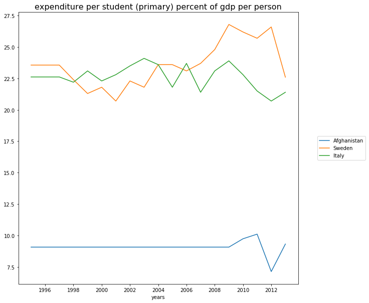

```python
# primary education expenditure by different countries

ax=plt.figure(figsize=(10,10)).gca()
for i in countries:
    y_pr= df_pr_ed_v2.loc[i]
    plt.plot(x,y_pr, label = i)

ax.legend(loc= 'center right', bbox_to_anchor= (1.25, 0.5))
ax.xaxis.set_major_locator(MaxNLocator(integer=True))
plt.title('expenditure per student (primary) percent of gdp per person', fontsize= 16)
plt.xlabel('years');
```

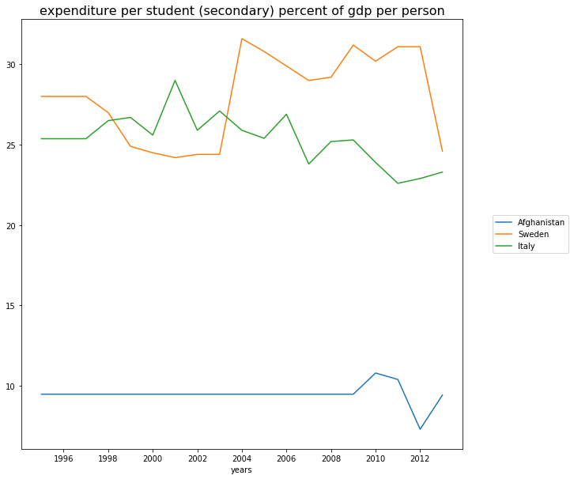

```python
# Secondary education expenditure by different countries

ax=plt.figure(figsize=(10,10)).gca()
for i in countries:
    y_se= df_se_ed_v2.loc[i]
    plt.plot(x,y_se, label = i)

ax.legend(loc= 'center right', bbox_to_anchor= (1.25, 0.5))
ax.xaxis.set_major_locator(MaxNLocator(integer=True))
plt.title('expenditure per student (secondary) percent of gdp per person', fontsize= 16)
plt.xlabel('years');
```

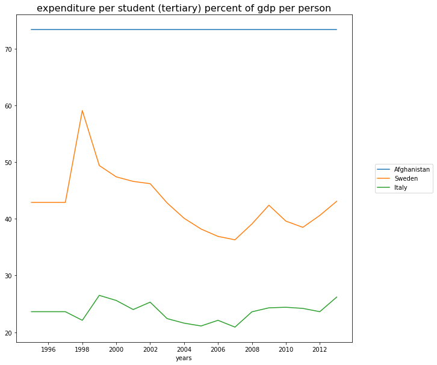

```python
# Tertiary education expenditure by different countries

ax=plt.figure(figsize=(10,10)).gca()
for i in countries:
    y_te= df_te_ed_v2.loc[i]
    plt.plot(x,y_te, label = i)

ax.legend(loc= 'center right', bbox_to_anchor= (1.25, 0.5))
ax.xaxis.set_major_locator(MaxNLocator(integer=True))
plt.title('expenditure per student (tertiary) percent of gdp per person', fontsize= 16)
plt.xlabel('years');
```

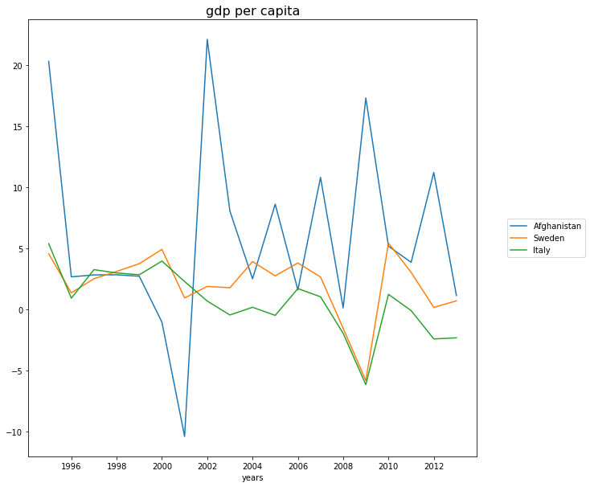

```python
#GDP variation of countries

ax=plt.figure(figsize=(10,10)).gca()
for i in countries:
    y_gdp= df_gdp_p_cap_yrl_v2.loc[i]
    plt.plot(x,y_gdp, label = i)

ax.legend(loc= 'center right', bbox_to_anchor= (1.25, 0.5))
ax.xaxis.set_major_locator(MaxNLocator(integer=True))
plt.title('gdp per capita', fontsize= 16)
plt.xlabel('years');
```

### Inferences from above plots

1. In terms of primary and secondary education Sweden and Italy consistently spent more, however for tertiary education Afghanistan spent more by a significant margin.
2. It should be noted that the tertiary eduction expenditure plot for Afghanistan is constant which signifies only a year value is reported. It signifies the limitation of subsituting NA's with average values. Therefore, it would be improper to conclude on the country's expenditure based on the given data.
3. Sweden is a better GDP per capita performer when compared to Italy. What is interesting is that around year 2000 and onward, the growth rate of Italy has reduced to negtive numbers and that has impacted education expenditure specifically primary and secondary where it crosses line with Sweden.
4. Another interesting pattern could be noted in variation of GDP growth rate of Afghanistan. The variaton rate is extremely volatile as compared to its counterparts. It could attributed to the amount of financial aid Afghanistan receives. We will test this hypothesis in the next section.

```python
df_aids = pd.read_csv('aid_received_per_person_current_us.csv', index_col= 0)
```

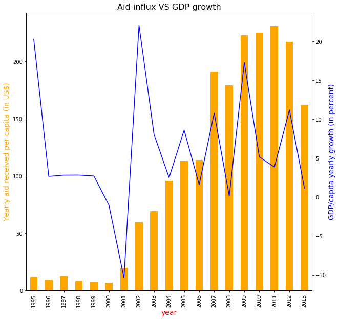

```python
#Plot aids received per person vs GDP/capita growth for Afghanistan

fig,ax1= plt.subplots(figsize=(10,10))
ax1= df_aids.loc['Afghanistan', cols].plot.bar(color= 'orange')
ax1.set_xlabel('year', fontsize=14, color= 'red')
ax1.set_ylabel('Yearly aid received per capita (in US$)', fontsize=14, color= 'orange')
ax2= ax1.twinx()
ax2= df_gdp_p_cap_yrl_v2.loc['Afghanistan', cols].plot(color= 'blue')
ax2.set_ylabel('GDP/capita yearly growth (in percent)', fontsize=14, color= 'blue')
plt.title('Aid influx VS GDP growth', fontsize= 16)
plt.show();
```

### Correlation b/w aid influx and GDP growth

From the above fig although it seems the aid influx does impact GDP but we cannot consluively infer that financial aid to Afghanistan directly impacts the GDP of the country and in turn education expenditure. More information is required to reach a conclusion as to what is causing the volatility in GDP growth rate.

### How does the GDP growth of different countries compared? Is there any correlation b/w expenditure per student and GDP per capita?

1. GDP of OECD countries are compared using through boxplot and a line chart
2. A function is created to plot the GDP vs education expenditures of different countries

```python
#List of founding OECD countries
oecd=['Austria','Belgium','Denmark','France','Germany','Iceland','Ireland','Italy','Netherlands','New Zealand','Norway','Portugal','Spain','Sweden','Switzerland','Turkey','United Kingdom','United States']
#oecd.replace(u'\xa0', u'')
```

```python
oecd
```

```
['Austria',
 'Belgium',
 'Denmark',
 'France',
 'Germany',
 'Iceland',
 'Ireland',
 'Italy',
 'Netherlands',
 'New Zealand',
 'Norway',
 'Portugal',
 'Spain',
 'Sweden',
 'Switzerland',
 'Turkey',
 'United Kingdom',
 'United States']
```

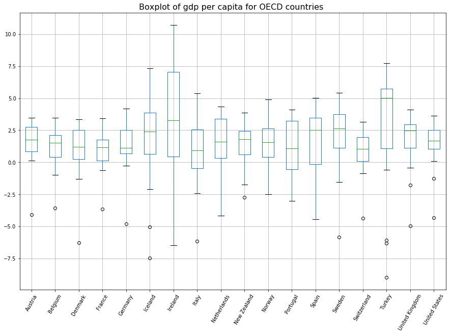

```python
#Boxplot of avg GDP of OECD countries

ax=plt.figure(figsize=(15,10)).gca()

df_gdp_p_cap_yrl_v2.loc[oecd].T.boxplot()
plt.xticks(rotation = 60)
plt.title('Boxplot of gdp per capita for OECD countries ', fontsize= 16);
```

### Conclusion on summary boxplot

1. Its quite interesting to note that the mean GDP rate of almost all OECD countries lie b/w 0-2.5 with exception of Ireland and Turkey.
2. Ireland's GDP had most variation whereas USA's econonomy has been consistent over the given years.
3. Almost all countries had an outlier at the negative side. This could be a global phenomenon which affected all countries and brought them down. A time series graph of the economies might serve an answer.

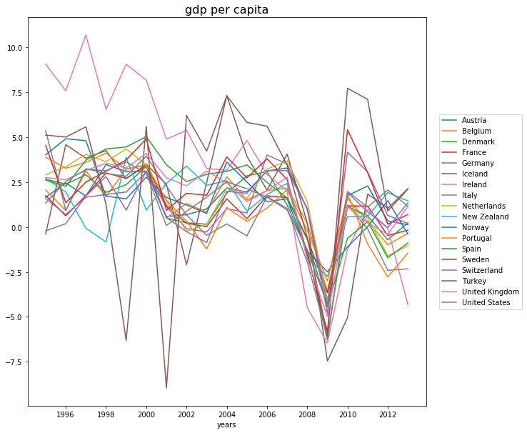

```python
#GDP variation of OECD countries

ax=plt.figure(figsize=(10,10)).gca()
for i in oecd:
    y_gdp= df_gdp_p_cap_yrl_v2.loc[i]
    plt.plot(x,y_gdp, label = i)

ax.legend(loc= 'center right', bbox_to_anchor= (1.25, 0.5))
ax.xaxis.set_major_locator(MaxNLocator(integer=True))
plt.title('gdp per capita', fontsize= 16)
plt.xlabel('years');
```

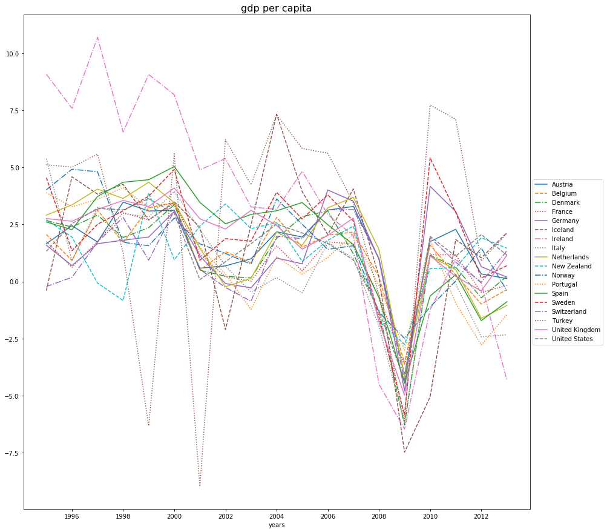

```python
#In the earlier plot the line colors are cycled which is making it difficult to differentiate b/w
#different countries. Hence we take help of the line type.

from itertools import cycle
lines = ["-","--","-.",":"]
linecycler = cycle(lines)

ax=plt.figure(figsize=(15,15)).gca()
for i in oecd:
    y_gdp= df_gdp_p_cap_yrl_v2.loc[i]
    plt.plot(x,y_gdp, next(linecycler), label = i)

ax.legend(loc= 'center right', bbox_to_anchor= (1.15, 0.5))
ax.xaxis.set_major_locator(MaxNLocator(integer=True))
plt.title('gdp per capita', fontsize= 16)
plt.xlabel('years');
```

We can see on the above plot that almost all countries faced a sharp decline in GDP per capita around the period of 2007-2008. Our hypothesis in the previous section of a global phenomenon affecting the countries is justified. This could be attributed to the global recession that occurred during the period.

```python
# Use this, and more code cells, to explore your data. Don't forget to add
#   Markdown cells to document your observations and findings.

#education expenditure of countries
#country='Norway'

def plot_data (country):
    x1= list(range(1995, 2014))
    y1= df_gdp_p_cap_yrl_v2.loc[country]
    y2= df_pr_ed_v2.loc[country]
    y3= df_se_ed_v2.loc[country]
    y4= df_te_ed_v2.loc[country]
    ax=plt.figure(figsize=(10,10)).gca()
    plt.title(country, fontsize= 16)
    plt.plot(x1, y1, label= 'GDP per capita')
    plt.plot(x1, y2, label= 'exp. per capita in primary education')
    plt.plot(x1, y3, label= 'exp. per capita in secondary education')
    plt.plot(x1, y4, label= 'exp. per capita in tertiary education')
    ax.xaxis.set_major_locator(MaxNLocator(integer=True))
    ax.legend(loc= 'center right', bbox_to_anchor= (1.45, 0.5))
    plt.show()
```

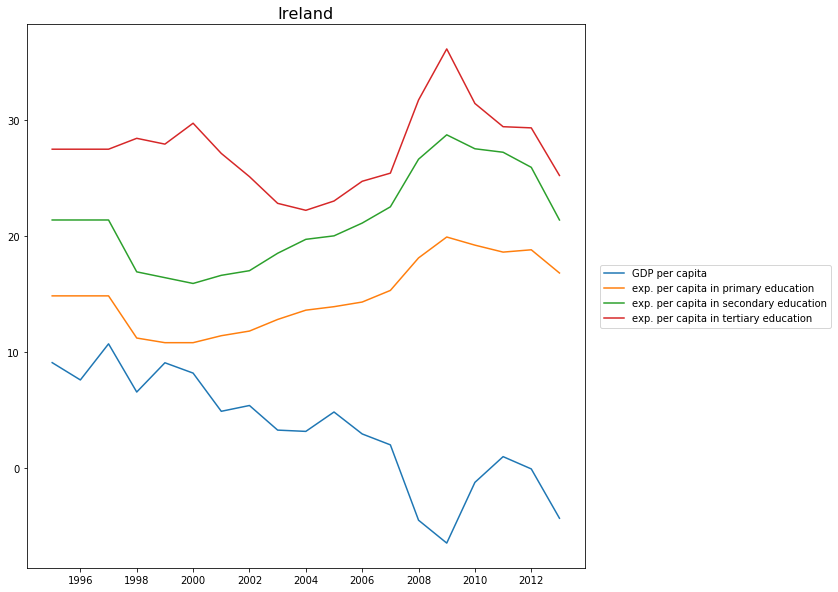

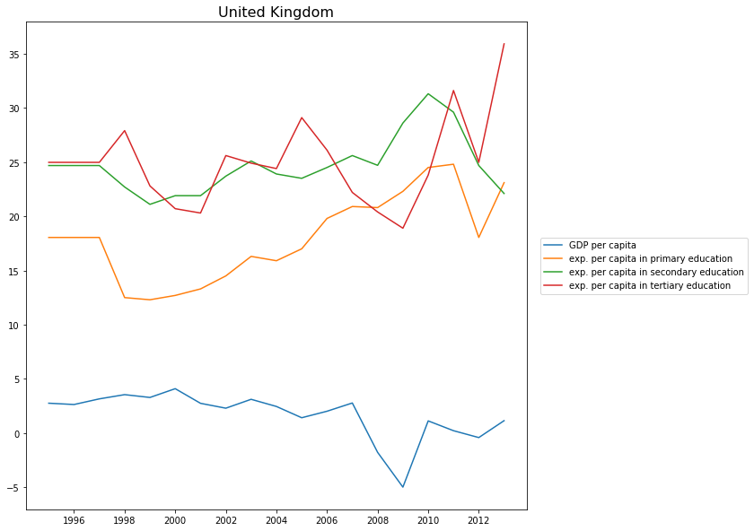

```python
plot_data('Ireland'); plot_data('United Kingdom')
```

## Conclusions

Datasets representing different indicators of countries across the globe are replete with null values and it is important to clean up or ammend these values to get sensible results.Once the shapes and the values of the datasets are consistent then the plots of datasets could reveal interesting trends as we saw in the case of economies affected by recession. However, sometimes it is difficult to answer some questions through visual plots only. For instance, in case of correlation between aid and GDP growth, correlation b/w GDP growth and education expenditure could not be judged through plots rather, a correlation coefficient is needed.